# OMICS TECHNIQUES

EXERCISE 1 - Introduction to Bioconductor, Rmarkdown and Github

Alba Malagón Márquez

19 May 2020

- **Link of my repository**: https://github.com/albamalagon/omics_techniques.git
- **Link of the study**: https://www.ncbi.nlm.nih.gov/geo/query/acc.cgi?acc=GSE147964
- **Title**: Expression data from healthy subjects and patients with M. africanum or M. tuberculosis infection
- **Identifier**: GSE147964
- **Description of the study**: A blood transcriptome analysis was performed on a set of healthy subjects and patients infected with M. africanum (MAF) or M. tuberculosis (MTB). All study participants were recruited from Mali.
- **Experimental design information**:
- **Number of samples**: 30
- **Experiment type**: Expression profiling by array
- **Groups analysed**: 3
- 10 blood from a healthy subject
- 10 blood from a patient with M. tuberculosis infection
- 10 blood from a patient with M. africanum infection

These are the different samples:

| Group | Sample | Title | Disease Status |
| --- | --- | --- | --- |
| group 1 | sample 1 | healthy 1 | Healthy |
| group 1 | sample 2 | healthy 2 | Healthy |
| group 1 | sample 3 | healthy 3 | Healthy |
| group 1 | sample 4 | healthy 4 | Healthy |
| group 1 | sample 5 | healthy 5 | Healthy |
| group 1 | sample 6 | healthy 6 | Healthy |
| group 1 | sample 7 | healthy 7 | Healthy |
| group 1 | sample 8 | healthy 8 | Healthy |
| group 1 | sample 9 | healthy 9 | Healthy |
| group 1 | sample 10 | healthy 10 | Healthy |
| group 2 | sample 11 | MTB 1 | M. tuberculosis infection |
| group 2 | sample 12 | MTB 2 | M. tuberculosis infection |
| group 2 | sample 13 | MTB 3 | M. tuberculosis infection |
| group 2 | sample 14 | MTB 4 | M. tuberculosis infection |
| group 2 | sample 15 | MTB 5 | M. tuberculosis infection |
| group 2 | sample 16 | MTB 6 | M. tuberculosis infection |
| group 2 | sample 17 | MTB 7 | M. tuberculosis infection |
| group 2 | sample 18 | MTB 8 | M. tuberculosis infection |
| group 2 | sample 19 | MTB 9 | M. tuberculosis infection |
| group 2 | sample 20 | MTB 10 | M. tuberculosis infection |
| group 3 | sample 21 | MAF 1 | M. africanum infection |
| group 3 | sample 22 | MAF 2 | M. africanum infection |
| group 3 | sample 23 | MAF 3 | M. africanum infection |
| group 3 | sample 24 | MAF 4 | M. africanum infection |
| group 3 | sample 25 | MAF 5 | M. africanum infection |
| group 3 | sample 26 | MAF 6 | M. africanum infection |
| group 3 | sample 27 | MAF 7 | M. africanum infection |
| group 3 | sample 28 | MAF 8 | M. africanum infection |
| group 3 | sample 29 | MAF 9 | M. africanum infection |
| group 3 | sample 30 | MAF 10 | M. africanum infection |

# 1 DESCRIPTION OF THE DATA

First we need to extract the data by downloading it directly from the GEO database.

```r
mydata <- getGEO("GSE147964", GSEMatrix =TRUE, getGPL=FALSE, parseCharacteristics = TRUE)
```

```
## Found 1 file(s)
```

```
## GSE147964_series_matrix.txt.gz
```

We need to transform the data into an Expression set. By showing its information we can observe the different fields of the ExpressionSet object.

```r
eset <- mydata[[1]]
show(eset)
```

```
## ExpressionSet (storageMode: lockedEnvironment)
## assayData: 135750 features, 30 samples
##   element names: exprs
## protocolData: none
## phenoData
##   sampleNames: GSM4451044 GSM4451045 ... GSM4451073 (30 total)
##   varLabels: title geo_accession ... tissue:ch1 (33 total)
##   varMetadata: labelDescription
## featureData: none
## experimentData: use 'experimentData(object)'
## Annotation: GPL23126
```

This study contains 135750 features, which represent the rows of the matrix, and each of them has information about 30 different samples, which correspond to the columns.

```
## Features  Samples
##   135750       30
```

With the function colnames() we can obtain the different names of the columns, which in fact are the names of the samples.

```
##  [1] "GSM4451044" "GSM4451045" "GSM4451046" "GSM4451047" "GSM4451048"
##  [6] "GSM4451049" "GSM4451050" "GSM4451051" "GSM4451052" "GSM4451053"
## [11] "GSM4451054" "GSM4451055" "GSM4451056" "GSM4451057" "GSM4451058"
## [16] "GSM4451059" "GSM4451060" "GSM4451061" "GSM4451062" "GSM4451063"
## [21] "GSM4451064" "GSM4451065" "GSM4451066" "GSM4451067" "GSM4451068"
## [26] "GSM4451069" "GSM4451070" "GSM4451071" "GSM4451072" "GSM4451073"
```

We can also take a look at the different properties each sample has, although in this case we have only selected some of them to be displayed.

```r
head(pData(eset)[c(1,11,9,18)])
```

```
##                title   characteristics_ch1.1 organism_ch1
## GSM4451044 Healthy 1 disease status: Healthy Homo sapiens
## GSM4451045 Healthy 2 disease status: Healthy Homo sapiens
## GSM4451046 Healthy 3 disease status: Healthy Homo sapiens
## GSM4451047 Healthy 4 disease status: Healthy Homo sapiens
## GSM4451048 Healthy 5 disease status: Healthy Homo sapiens
## GSM4451049 Healthy 6 disease status: Healthy Homo sapiens
##                       scan_protocol
## GSM4451044 Per Affymetrix protocol.
## GSM4451045 Per Affymetrix protocol.
## GSM4451046 Per Affymetrix protocol.
## GSM4451047 Per Affymetrix protocol.
## GSM4451048 Per Affymetrix protocol.
## GSM4451049 Per Affymetrix protocol.
```

We can also take extract small expressionsets from the complete one. In this case, we will make a small expression set for each group: healthy subjects, subjects with the disease M. tuberculosis and a third group of subjects with the disease M. africanum.

```r
smallEset_group1 <- eset[,1:10] #healthy
smallEset_group2 <- eset[,11:20] #m. tuberculosis
smallEset_group3 <- eset[,21:30] #m. africanum
```

We will give a brief description of the data by analysing some numerical summaries and displaying different types of plots.

## 1.1 NUMERICAL SUMMARIES

First of all, we need to extract the expression data from the whole ExpressionSet object.

```r
expression_values <- exprs(eset)
```

In order to display some statistical parameters of each sample we can use the function summary(). We obtain the minimum, the mean, the median and the maximum of the data, as well as the quartiles.

```
##    GSM4451044        GSM4451045        GSM4451046        GSM4451047
##  Min.   : 0.6523   Min.   : 0.6259   Min.   : 0.4981   Min.   : 0.6407
##  1st Qu.: 1.8467   1st Qu.: 1.7864   1st Qu.: 1.7824   1st Qu.: 1.9003
##  Median : 2.6279   Median : 2.5676   Median : 2.5691   Median : 2.6122
##  Mean   : 3.1090   Mean   : 3.1046   Mean   : 3.1049   Mean   : 3.1039
##  3rd Qu.: 3.9189   3rd Qu.: 3.9164   3rd Qu.: 3.9136   3rd Qu.: 3.8132
##  Max.   :13.3775   Max.   :13.7323   Max.   :13.6324   Max.   :13.5650
##    GSM4451048        GSM4451049        GSM4451050        GSM4451051
##  Min.   : 0.6442   Min.   : 0.5935   Min.   : 0.6208   Min.   : 0.5818
##  1st Qu.: 1.8273   1st Qu.: 1.7922   1st Qu.: 1.9135   1st Qu.: 1.8293
##  Median : 2.6006   Median : 2.5723   Median : 2.6460   Median : 2.5855
##  Mean   : 3.1094   Mean   : 3.0957   Mean   : 3.1066   Mean   : 3.1012
##  3rd Qu.: 3.9051   3rd Qu.: 3.9046   3rd Qu.: 3.8215   3rd Qu.: 3.8780
##  Max.   :13.6983   Max.   :13.4040   Max.   :13.5228   Max.   :13.5226
##    GSM4451052        GSM4451053        GSM4451054        GSM4451055
##  Min.   : 0.6258   Min.   : 0.6023   Min.   : 0.5759   Min.   : 0.6372
##  1st Qu.: 1.7949   1st Qu.: 1.7773   1st Qu.: 1.8175   1st Qu.: 1.8503
##  Median : 2.5508   Median : 2.5539   Median : 2.6109   Median : 2.6065
##  Mean   : 3.0916   Mean   : 3.0926   Mean   : 3.1126   Mean   : 3.1127
##  3rd Qu.: 3.8662   3rd Qu.: 3.8988   3rd Qu.: 3.9320   3rd Qu.: 3.8904
##  Max.   :13.4752   Max.   :13.5171   Max.   :13.6830   Max.   :13.5070
##    GSM4451056        GSM4451057        GSM4451058        GSM4451059
##  Min.   : 0.6687   Min.   : 0.5709   Min.   : 0.6525   Min.   : 0.623
##  1st Qu.: 1.7672   1st Qu.: 1.8114   1st Qu.: 1.8420   1st Qu.: 1.828
##  Median : 2.5549   Median : 2.5969   Median : 2.5944   Median : 2.581
##  Mean   : 3.1050   Mean   : 3.1073   Mean   : 3.1112   Mean   : 3.105
##  3rd Qu.: 3.9235   3rd Qu.: 3.9186   3rd Qu.: 3.8839   3rd Qu.: 3.867
##  Max.   :13.3824   Max.   :13.6203   Max.   :13.7028   Max.   :13.641
##    GSM4451060        GSM4451061        GSM4451062        GSM4451063
##  Min.   : 0.6293   Min.   : 0.6223   Min.   : 0.6391   Min.   : 0.6337
##  1st Qu.: 1.8278   1st Qu.: 1.8242   1st Qu.: 1.7899   1st Qu.: 1.8056
##  Median : 2.6031   Median : 2.5649   Median : 2.5787   Median : 2.5941
##  Mean   : 3.1159   Mean   : 3.0973   Mean   : 3.1036   Mean   : 3.1108
##  3rd Qu.: 3.9097   3rd Qu.: 3.8523   3rd Qu.: 3.9118   3rd Qu.: 3.9233
##  Max.   :13.4980   Max.   :13.7048   Max.   :13.5310   Max.   :13.7083
##    GSM4451064        GSM4451065        GSM4451066        GSM4451067
##  Min.   : 0.6076   Min.   : 0.6162   Min.   : 0.6021   Min.   : 0.591
##  1st Qu.: 1.8434   1st Qu.: 1.8780   1st Qu.: 1.8410   1st Qu.: 1.810
##  Median : 2.6264   Median : 2.6294   Median : 2.5995   Median : 2.586
##  Mean   : 3.1131   Mean   : 3.1100   Mean   : 3.1125   Mean   : 3.109
##  3rd Qu.: 3.9212   3rd Qu.: 3.8778   3rd Qu.: 3.8903   3rd Qu.: 3.913
##  Max.   :13.6108   Max.   :13.7236   Max.   :13.7795   Max.   :13.586
##    GSM4451068       GSM4451069        GSM4451070        GSM4451071
##  Min.   : 0.591   Min.   : 0.6755   Min.   : 0.6305   Min.   : 0.6577
##  1st Qu.: 1.796   1st Qu.: 1.7879   1st Qu.: 1.7837   1st Qu.: 1.8735
##  Median : 2.570   Median : 2.5823   Median : 2.5697   Median : 2.6098
##  Mean   : 3.102   Mean   : 3.1067   Mean   : 3.1034   Mean   : 3.1130
##  3rd Qu.: 3.898   3rd Qu.: 3.9248   3rd Qu.: 3.9067   3rd Qu.: 3.8640
##  Max.   :13.667   Max.   :13.1953   Max.   :13.3262   Max.   :13.6506
##    GSM4451072        GSM4451073
##  Min.   : 0.6348   Min.   : 0.6231
##  1st Qu.: 1.8358   1st Qu.: 1.7783
##  Median : 2.6002   Median : 2.5783
##  Mean   : 3.1111   Mean   : 3.1025
##  3rd Qu.: 3.8902   3rd Qu.: 3.9206
##  Max.   :13.6480   Max.   :13.2249
```

We can also select only one column, which would mean that we are just analysing specific samples.

```r
summary(expression_values[,4]) #sample in column number 4
```

```
##    Min. 1st Qu.  Median    Mean 3rd Qu.    Max.
##  0.6407  1.9003  2.6122  3.1039  3.8132 13.5650
```

```r
summary(expression_values[,20]) #sample in column number 20
```

```
##    Min. 1st Qu.  Median    Mean 3rd Qu.    Max.
##  0.6337  1.8056  2.5941  3.1108  3.9233 13.7083
```

We can also do some summaries for each specific group. In this case, we will get the maximum, the mean and the minimum for each group.

GROUP 1: healthy subjects

```
## [1] "Min: 0.498141"
```

```
## [1] "Mean: 3.10195092053481"
```

```
## [1] "Max: 13.7323"
```

GROUP 2: subjects with M. tuberculosis

```
## [1] "Min: 0.570902"
```

```
## [1] "Mean: 3.1081876868663"
```

```
## [1] "Max: 13.7083"
```

GROUP 3: subjects with M. africanum

```
## [1] "Min: 0.590951"
```

```
## [1] "Mean: 3.10833322056501"
```

```
## [1] "Max: 13.7795"
```

From this information, we can guess that the shape of the values’ distribution will be skewed, as the values of the whole samples are slightly different for each sample. Hence, in order to compare the different samples, we would first need to normalize the values.

## 1.2 PLOTS

Now we will show some plots in order to observe the same information as before, but from a graphical point of view.

### 1.2.1 Histogram

This histogram shows the distribution of expression values for the whole data.

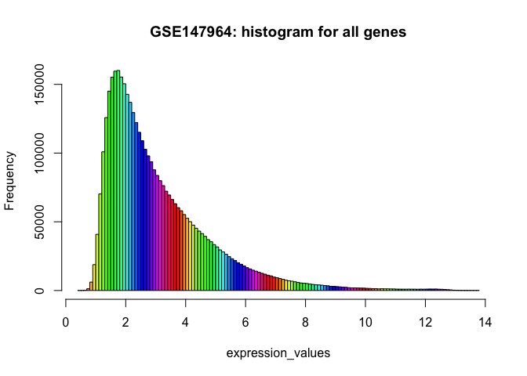

This histogram shows the distribution of expression values for a specific gene: the gene number 10.

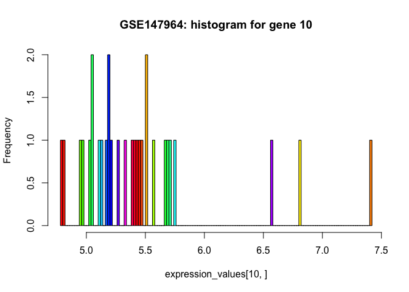

In the case of the histogram for the whole data, we can observe that the data is not symmetric; hence, we need to normalize the values by using the logarithm. We obtain a more symmetric distribution:

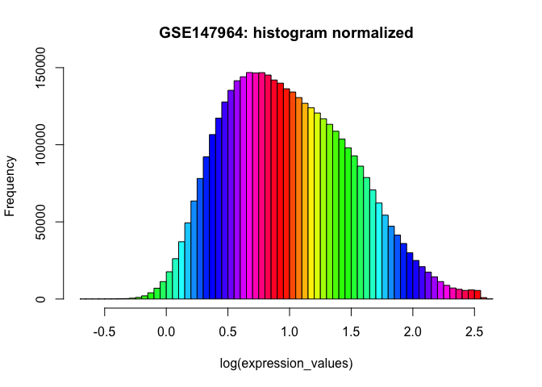

### 1.2.2 Boxplot

We can also plot different boxplots for our data. Each sample is colored depending on the group it belongs to.

- **Orange**: healthy subjects (group1)
- **Purple**: subjects with M. tuberculosis (group2)
- **Pink**: subjects with M. africanum (group3)

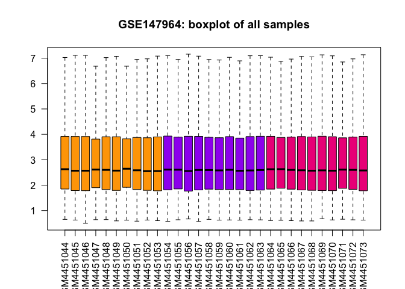

By normalizing the data, we obtain the following plot:

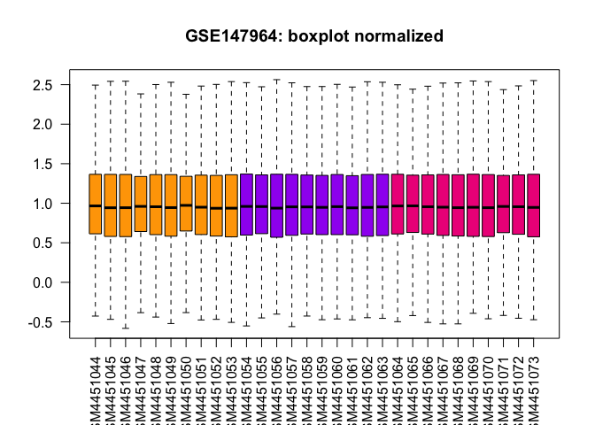

We can also make plots for each specific group. In this case we will only do it for the group of healthy individuals.

GROUP 1: healthy subjects

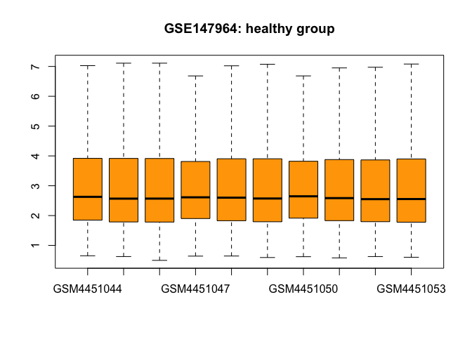

We can also normalize the values in order to compare the samples.

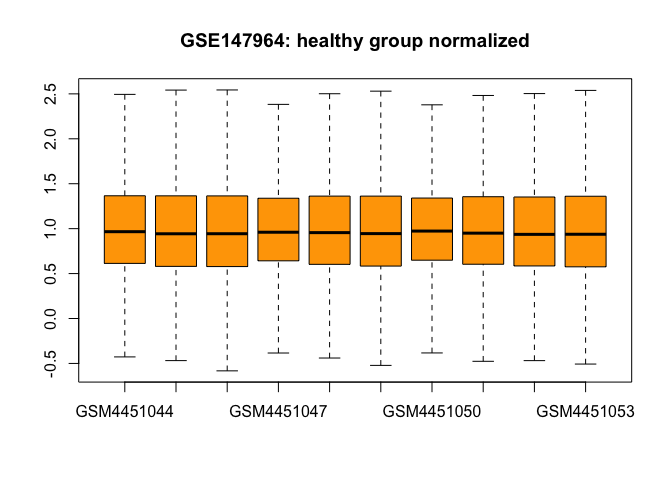

### 1.2.3 Barplot

A barplot also allows as to show graphically the expression of one gene in each of the samples.

Here is the example of the expression for the first gene. We can observe that the levels of expressions are not the same in each group.

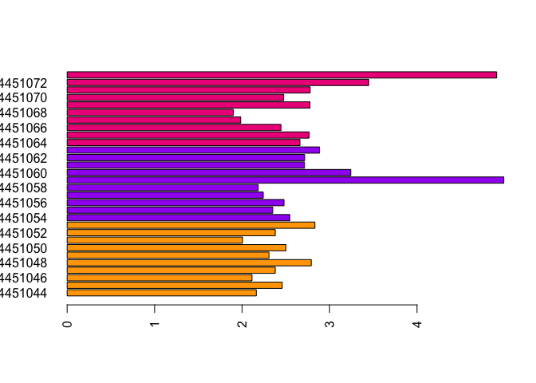

Here is the example of the expression for the gene number 16. We can observe that the levels of expressions are more or less the same in each group.

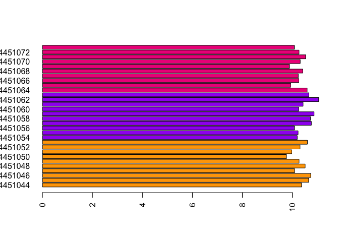

### 1.2.4 Principal Component Analysis

Now we will perform a principal component analysis.

We can plot a barplot of the deviation values of the PCA.

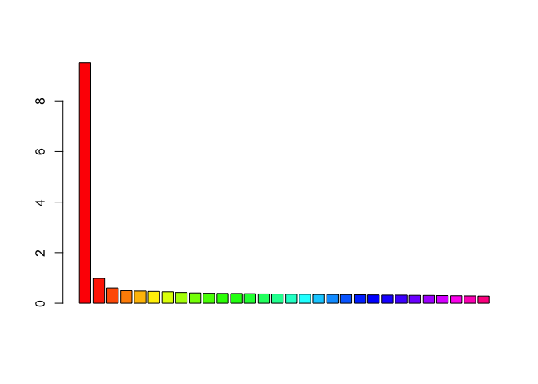

Here we get a representation of the first two principal components. The group of healthy individuals are represented with an H. The group of individuals with M. Tuberculosis are represented with a T. The group of individuals with M. Africanum are represented with an A.

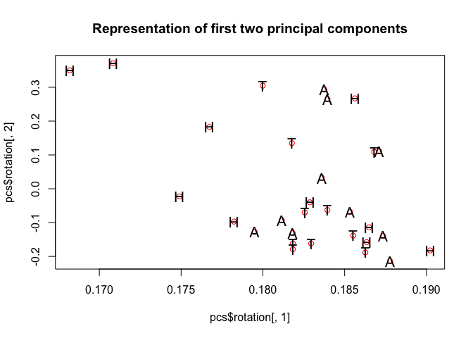

The top variable genes can be sorted.

```r
genes <- rownames(expression_values)
variab <- apply(expression_values, 1, sd)
orderedGenes <- genes[order(variab, decreasing=TRUE)]
```

We can analyse the level of expression of the 3 top genes by using barplots. Its color depend on the group they belong to.

TOP 1 GENE:

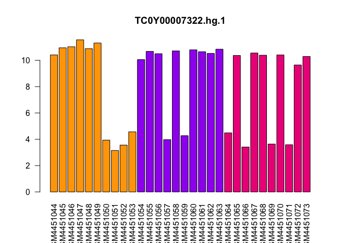

TOP 2 GENE:

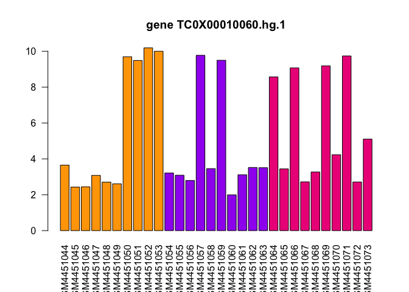

TOP 3 GENE:

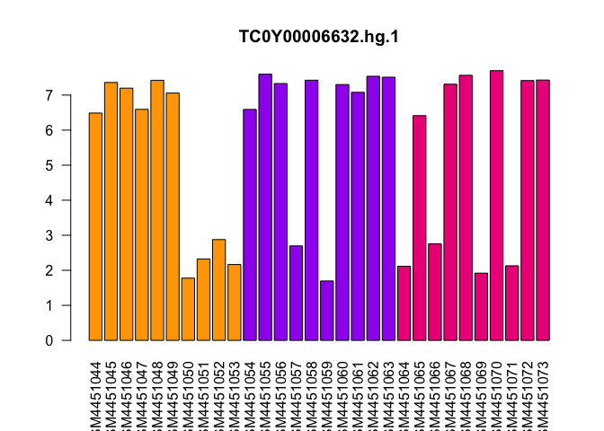